# Earth Microbiome Vuegen Demo Notebook

The Earth Microbiome Project (EMP) is a systematic attempt to characterize global microbial taxonomic and functional diversity for the benefit of the planet and humankind. It aimed to sample the Earth’s microbial communities at an unprecedented scale in order to advance our understanding of the organizing biogeographic principles that govern microbial community structure. The EMP dataset is generated from samples that individual researchers have compiled and contributed to the EMP. The result is both a reference database giving global context to DNA sequence data and a framework for incorporating data from future studies, fostering increasingly complete characterization of Earth’s microbial diversity.

You can find more information about the Earth Microbiome Project at https://earthmicrobiome.org/ and in the [original article](https://www.nature.com/articles/nature24621).

[figure not shown]

# Exploratory Data Analysis

This section contains the exploratory data analysis of the Earth Microbiome Project (EMP) dataset.

## Sample Exploration

### Metadata Random Subset

| <sup>[ⓘ](https://itables.org/fallbacks/static_preview.html)</sup>#SampleID | BarcodeSequence | LinkerPrimerSequence | Description | host_subject_id | study_id | title | principal_investigator | doi | ebi_accession | target_gene | target_subfragment | pcr_primers | illumina_technology | extraction_center | run_center | run_date | read_length_bp | sequences_split_libraries | observations_closed_ref_greengenes | observations_closed_ref_silva | observations_open_ref_greengenes | observations_deblur_90bp | observations_deblur_100bp | observations_deblur_150bp | emp_release1 | qc_filtered | subset_10k | subset_5k | subset_2k | … |
| --- | --- | --- | --- | --- | --- | --- | --- | --- | --- | --- | --- | --- | --- | --- | --- | --- | --- | --- | --- | --- | --- | --- | --- | --- | --- | --- | --- | --- | --- | --- |
| 1056.Mel.urs.ino.SanDi.1 | CGATAGGCCTTA | GTGCCAGCMGCCGCGGTAA | fecal sample from Sri Lankan sloth bear | 1056:Mel.urs.ino.SanDi.1 | 1056 | Convergence of gut microbiomes in myrmecophagous mammals | Frederic Delsuc | 10.1111/mec.12501 | ERP003782 | 16S rRNA | V4 | FWD:GTGCCAGCMGCCGCGGTAA; REV:GGACTACHVGGGTWTCTAAT | MiSeq | CCME-Boulder | CCME | 10/9/12 | 151 | 19043 | 17318.0 | 17597.0 | 18497.0 | 13608.0 | 13265.0 | 10851.0 | True | True | True | True | True | … |
| 1036.P.N.14.2.s.4.1.sequences | GGTTCCATTAGG | GTGCCAGCMGCCGCGGTAA | soil metagenome P_N_14_2 | XXQIITAXX | 1036 | Microbial communities of the deep unfrozen: Do microbes in taliks increase permafrost carbon vulnerability? | Jenni Hultman | 10.1038/ismej.2011.163* | ERP016588 | 16S rRNA | V4 | FWD:GTGCCAGCMGCCGCGGTAA; REV:GGACTACHVGGGTWTCTAAT | HiSeq | ANL-Chicago | CCME | 2/15/12 | 100 | 201124 | 165896.0 | 171547.0 | 198921.0 | 107368.0 | 77423.0 | 0.0 | True | True | True | False | False | … |
| 1034.CHI7 | CTGAAGGGCGAA | GTGCCAGCMGCCGCGGTAA | soil metagenome, AB | CHI7 | 1034 | Distinct microbial communities associated with buried soils in the Siberian tundra | Antje Gittel | 10.1038/ismej.2013.219 | ERP016735 | 16S rRNA | V4 | FWD:GTGCCAGCMGCCGCGGTAA; REV:GGACTACHVGGGTWTCTAAT | HiSeq | ANL-Chicago | CCME | 8/28/12 | 100 | 94168 | 74417.0 | 77196.0 | 92153.0 | 46391.0 | 46128.0 | 0.0 | True | True | False | False | False | … |

(97 more rows not shown)

### Animal Samples Map

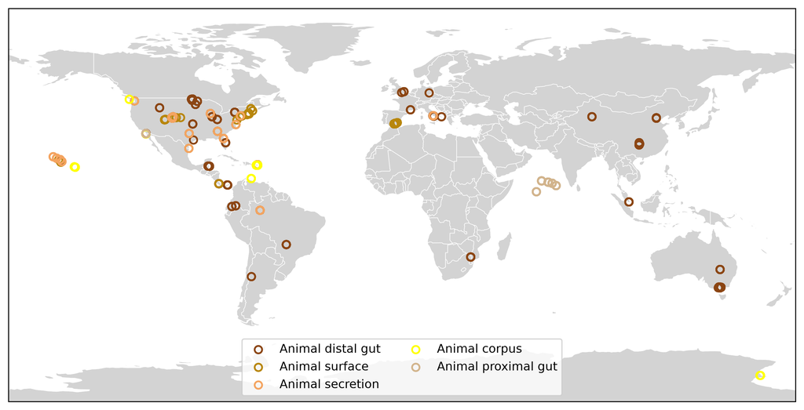

### Plant Samples Map

[interactive chart not shown]

### Saline Samples Map

[interactive chart not shown]

### Physicochemical properties of the EMP samples

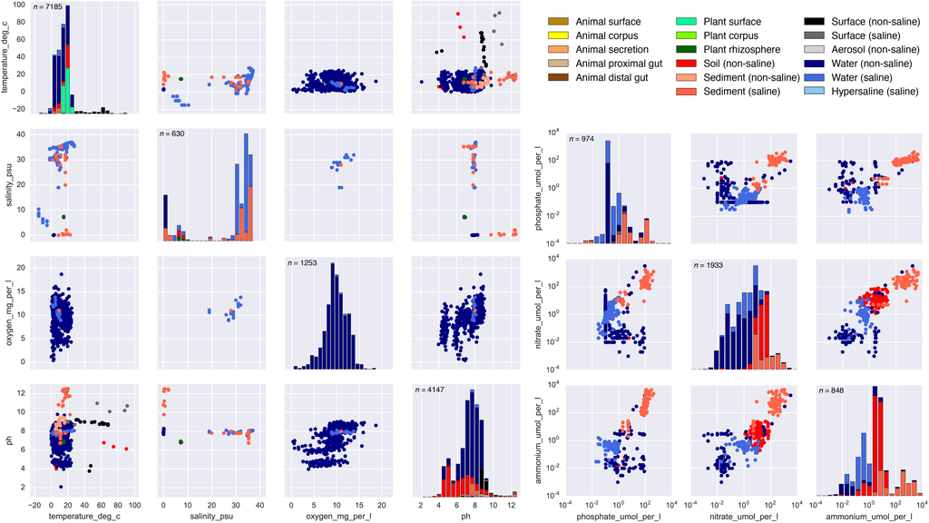

Pairwise scatter plots of available physicochemical metadat are shown for temperature, salinity, oxygen, and pH, and for phosphate, nitrate, and ammonium

# Metagenomics

## Alpha Diversity

This subsection contains the alpha diversity analysis of the EMP dataset.

### Alpha Diversity Host Associated Samples

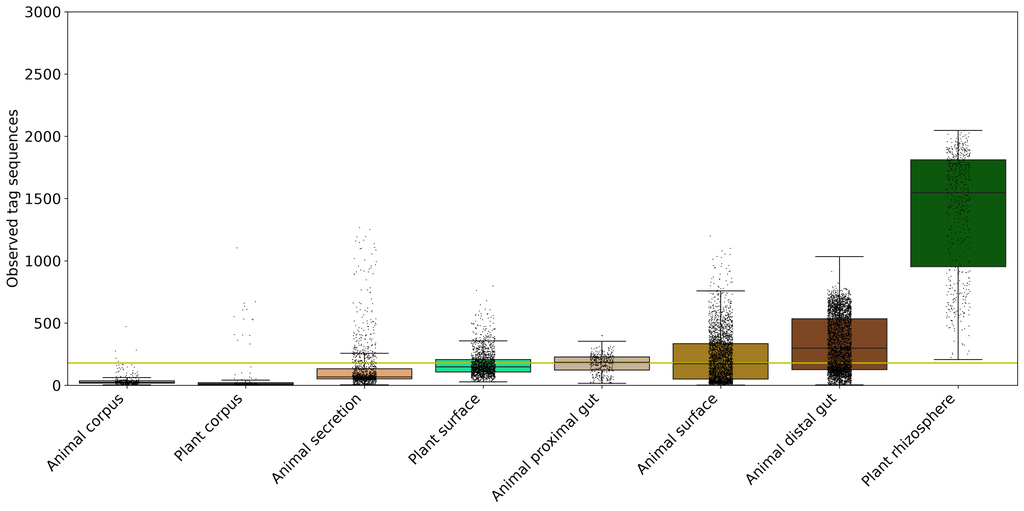

### Alpha Diversity Free Living Samples

[interactive chart not shown]

## Average Copy Number

### Average Copy Number Emp Ontology Level2

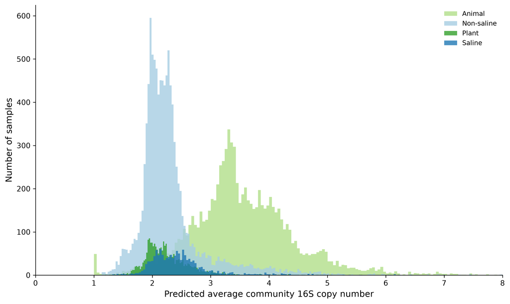

### Average Copy Number Emp Ontology Level3

[interactive chart not shown]

## Nestedness

### Nestedness Random Subset

| <sup>[ⓘ](https://itables.org/fallbacks/static_preview.html)</sup>Unnamed: 0 | SAMPLE_RANK | OBSERVATION_RANK | SAMPLE_ID | OBSERVATION_ID | empo_3 | METADATA_NUMERIC_CODE |
| --- | --- | --- | --- | --- | --- | --- |
| 15917 | 1577 | 84 | 808.AK.19.15a.s.4.1.sequences | k__Bacteria;p__Bacteroidetes | Soil (non-saline) | 9 |
| 6395 | 1871 | 70 | 807.S.S.11.b | k__Archaea;p__Euryarchaeota | Sediment (non-saline) | 11 |
| 4461 | 779 | 83 | 722.M11Tong.6.s.7.1.sequence | k__Bacteria;p__Actinobacteria | Animal secretion | 12 |

(97 more rows not shown)

### All Samples

[interactive chart not shown]

### Plant Samples

[interactive chart not shown]

### Animal Samples

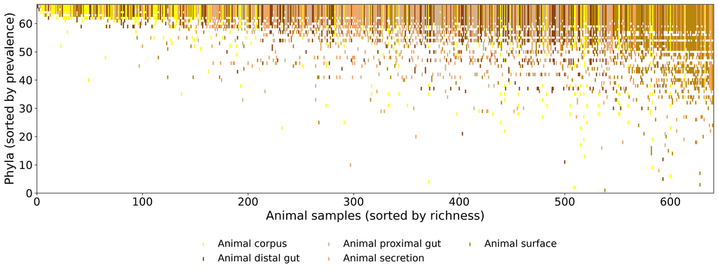

### Non Saline Samples

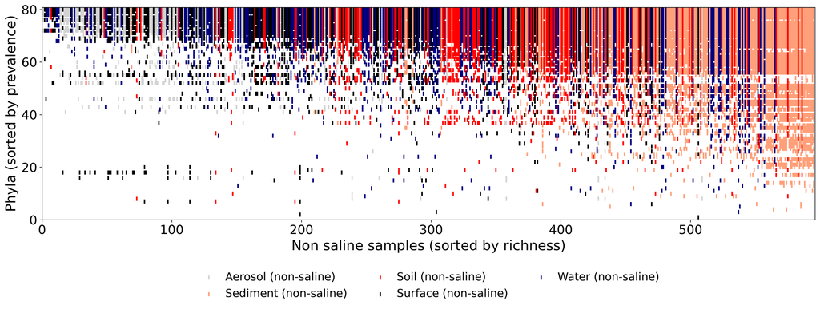

## Shanon entropy analysis

This subsection contains the Shannon entropy analysis of the EMP dataset.

### Specificity of sequences and higher taxonomic groups for environment

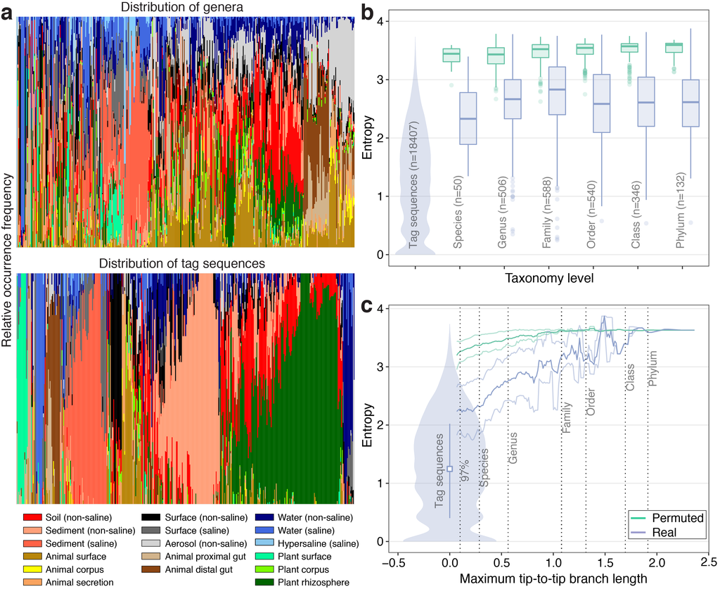

1. Environment distribution in all genera and 400 randomly chosen tag sequence. b) and c) Shannon entropy within each taxonomic group.

# Network Analysis

## Phyla Association Networks

### Phyla Counts Subset

| <sup>[ⓘ](https://itables.org/fallbacks/static_preview.html)</sup>Unnamed: 0 | 807.E.S.11.b | 1883.2008.269.Crump.Artic.LTREB.main.lane2.NoIndex | 1627.ZCCK1 | 1711.KAM6.3 | 1034.ZKD2 | 722.TRRsed3.4.s.4.1.sequence | 1883.2007.214.Crump.Artic.LTREB.main.lane2.NoIndex | 1222.B4.5.8.06 | 1288.NSB30jul08E.McMahon.Pool.3.and.1percentPhiX.110310.HWUSI.EAS552R.0357.s.3.1.sequence | 1242.ME07Aug08EB2R2 | 1453.47548SDZ2.C8.Cang.stom | 1642.MS00567 | 1198.ANT02.S1M2 | 1034.ZKE4 | 1580.1CA.sed.D1 | 550.L1S264.s.1.sequence | 1001.SKM9 | 1747.DZF.6202012.RJ.glass.window | 809.PLRP15.mat | 861.H10.mar09 | 1773.Columb.passer8.lgi | 933.Phylospora.comosa.1.5 | 1774.53Fecal23.10.09 | 678.T.RFLP.Sample.636 | 1883.2011.54.Crump.Artic.LTREB.main.lane3.NoIndex | 1642.MS00602 | 910.PocTA2 | 1039.L.Vermelha.SC.2.3 | 1748.5.15.12.FI.11.V | … |
| --- | --- | --- | --- | --- | --- | --- | --- | --- | --- | --- | --- | --- | --- | --- | --- | --- | --- | --- | --- | --- | --- | --- | --- | --- | --- | --- | --- | --- | --- | --- |
| Bacteroidetes | 0.037649 | 0.051275 | 0.123926 | 0.016145 | 0.027898 | 0.027252 | 0.048886 | 0.025186 | 0.029577 | 0.056765 | 0.104488 | 0.026542 | 0.052696 | 0.000000 | 0.094801 | 0.113335 | 0.049984 | 0.042686 | 0.069616 | 0.038876 | 0.008783 | 0.058573 | 0.028350 | 0.023184 | 0.048563 | 0.023636 | 0.002583 | 0.018211 | 0.020923 | … |
| WS3 | 0.012869 | 0.000000 | 0.000000 | 0.054504 | 0.000000 | 0.030280 | 0.016654 | 0.000000 | 0.000000 | 0.000757 | 0.000000 | 0.018925 | 0.000000 | 0.000000 | 0.010598 | 0.000000 | 0.000000 | 0.000000 | 0.006056 | 0.065102 | 0.000000 | 0.000000 | 0.000000 | 0.052233 | 0.004542 | 0.034065 | 0.000000 | 0.008327 | 0.000000 | … |
| Elusimicrobia | 0.021100 | 0.000000 | 0.000000 | 0.040693 | 0.000000 | 0.000000 | 0.018839 | 0.000000 | 0.000000 | 0.000000 | 0.000000 | 0.022607 | 0.000000 | 0.000000 | 0.000000 | 0.000000 | 0.000000 | 0.000000 | 0.000000 | 0.000000 | 0.000000 | 0.000000 | 0.002261 | 0.000754 | 0.003768 | 0.016579 | 0.000000 | 0.003014 | 0.000000 | … |

(78 more rows not shown)

### Phyla Correlation Network With 0.5 Threshold Edgelist

**Number of nodes:** 33

**Number of edges:** 42

[interactive chart not shown]

### Phyla Correlation Network With 0.5 Threshold

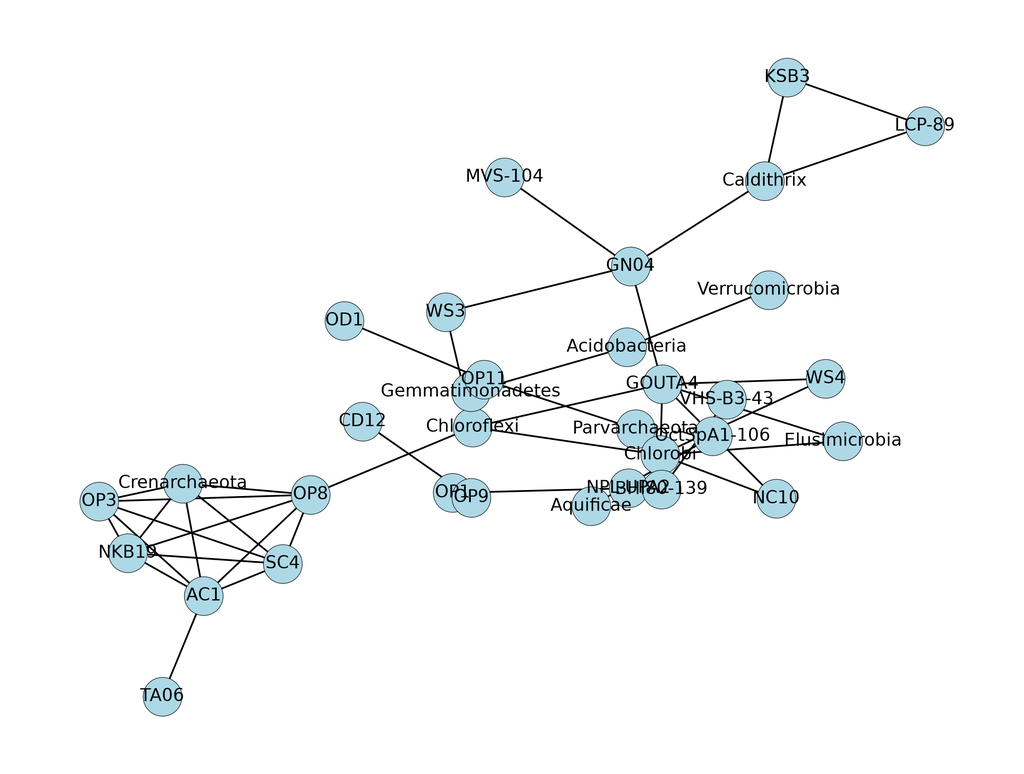